# Estudo de Caso: Detectando Câncer de Mama

## Por: Msc. Eng. Lucas Travi

## Curso: Machine Learning para Data Science - UFSM

## DESCRIÇÃO DO PROBLEMA

- Detectar se um tumor mamário é beligno ou maligno usando um classificador de suporte vetorial (SVC) através de um dataset com os seguintes atributos (inputs):
  - raio;
  - textura;
  - perímetro;
  - área;
  - concavidade;
  - suavidade;
  - compacidade;
  - pontos côncavos;
  - simetria;
  - dimensão fractal;
- Quantidade de observáveis: 569;
- Possibilidades (classes) de classificação (outputs):
  - Maligno;
  - Beligno;
- Distribuição entre as classes:
  - 212 malignos;
  - 357 belignos;
- Este dataset está disponível em: https://archive.ics.uci.edu/ml/datasets/Breast+Cancer+Wisconsin+(Diagnostic)

```python
# Importar as bibliotecas necessárias
import pandas as pd
import numpy as np
import matplotlib.pyplot as plt
import seaborn as sns
from IPython.display import display
```

```python
# Importar o dataset da biblioteca sklearn
from sklearn.datasets import load_breast_cancer
cancer = load_breast_cancer()
```

```python
cancer
```

```
{'data': array([[1.799e+01, 1.038e+01, 1.228e+02, ..., 2.654e-01, 4.601e-01,
         1.189e-01],
        [2.057e+01, 1.777e+01, 1.329e+02, ..., 1.860e-01, 2.750e-01,
         8.902e-02],
        [1.969e+01, 2.125e+01, 1.300e+02, ..., 2.430e-01, 3.613e-01,
         8.758e-02],
        ...,
        [1.660e+01, 2.808e+01, 1.083e+02, ..., 1.418e-01, 2.218e-01,
         7.820e-02],
        [2.060e+01, 2.933e+01, 1.401e+02, ..., 2.650e-01, 4.087e-01,
         1.240e-01],
        [7.760e+00, 2.454e+01, 4.792e+01, ..., 0.000e+00, 2.871e-01,
         7.039e-02]]),
 'target': array([0, 0, 0, 0, 0, 0, 0, 0, 0, 0, 0, 0, 0, 0, 0, 0, 0, 0, 0, 1, 1, 1,
        0, 0, 0, 0, 0, 0, 0, 0, 0, 0, 0, 0, 0, 0, 0, 1, 0, 0, 0, 0, 0, 0,
        0, 0, 1, 0, 1, 1, 1, 1, 1, 0, 0, 1, 0, 0, 1, 1, 1, 1, 0, 1, 0, 0,
        1, 1, 1, 1, 0, 1, 0, 0, 1, 0, 1, 0, 0, 1, 1, 1, 0, 0, 1, 0, 0, 0,
        1, 1, 1, 0, 1, 1, 0, 0, 1, 1, 1, 0, 0, 1, 1, 1, 1, 0, 1, 1, 0, 1,
        1, 1, 1, 1, 1, 1, 1, 0, 0, 0, 1, 0, 0, 1, 1, 1, 0, 0, 1, 0, 1, 0,
        0, 1, 0, 0, 1, 1, 0, 1, 1, 0, 1, 1, 1, 1, 0, 1, 1, 1, 1, 1, 1, 1,
        1, 1, 0, 1, 1, 1, 1, 0, 0, 1, 0, 1, 1, 0, 0, 1, 1, 0, 0, 1, 1, 1,
        1, 0, 1, 1, 0, 0, 0, 1, 0, 1, 0, 1, 1, 1, 0, 1, 1, 0, 0, 1, 0, 0,
        0, 0, 1, 0, 0, 0, 1, 0, 1, 0, 1, 1, 0, 1, 0, 0, 0, 0, 1, 1, 0, 0,
        1, 1, 1, 0, 1, 1, 1, 1, 1, 0, 0, 1, 1, 0, 1, 1, 0, 0, 1, 0, 1, 1,
        1, 1, 0, 1, 1, 1, 1, 1, 0, 1, 0, 0, 0, 0, 0, 0, 0, 0, 0, 0, 0, 0,
        0, 0, 1, 1, 1, 1, 1, 1, 0, 1, 0, 1, 1, 0, 1, 1, 0, 1, 0, 0, 1, 1,
        1, 1, 1, 1, 1, 1, 1, 1, 1, 1, 1, 0, 1, 1, 0, 1, 0, 1, 1, 1, 1, 1,
        1, 1, 1, 1, 1, 1, 1, 1, 1, 0, 1, 1, 1, 0, 1, 0, 1, 1, 1, 1, 0, 0,
        0, 1, 1, 1, 1, 0, 1, 0, 1, 0, 1, 1, 1, 0, 1, 1, 1, 1, 1, 1, 1, 0,
        0, 0, 1, 1, 1, 1, 1, 1, 1, 1, 1, 1, 1, 0, 0, 1, 0, 0, 0, 1, 0, 0,
        1, 1, 1, 1, 1, 0, 1, 1, 1, 1, 1, 0, 1, 1, 1, 0, 1, 1, 0, 0, 1, 1,
        1, 1, 1, 1, 0, 1, 1, 1, 1, 1, 1, 1, 0, 1, 1, 1, 1, 1, 0, 1, 1, 0,
        1, 1, 1, 1, 1, 1, 1, 1, 1, 1, 1, 1, 0, 1, 0, 0, 1, 0, 1, 1, 1, 1,
        1, 0, 1, 1, 0, 1, 0, 1, 1, 0, 1, 0, 1, 1, 1, 1, 1, 1, 1, 1, 0, 0,
        1, 1, 1, 1, 1, 1, 0, 1, 1, 1, 1, 1, 1, 1, 1, 1, 1, 0, 1, 1, 1, 1,
        1, 1, 1, 0, 1, 0, 1, 1, 0, 1, 1, 1, 1, 1, 0, 0, 1, 0, 1, 0, 1, 1,
        1, 1, 1, 0, 1, 1, 0, 1, 0, 1, 0, 0, 1, 1, 1, 0, 1, 1, 1, 1, 1, 1,
        1, 1, 1, 1, 1, 0, 1, 0, 0, 1, 1, 1, 1, 1, 1, 1, 1, 1, 1, 1, 1, 1,
        1, 1, 1, 1, 1, 1, 1, 1, 1, 1, 1, 1, 0, 0, 0, 0, 0, 0, 1]),
 'target_names': array(['malignant', 'benign'], dtype='<U9'),
 'DESCR': 'Breast Cancer Wisconsin (Diagnostic) Database\n=============================================\n\nNotes\n-----\nData Set Characteristics:\n    :Number of Instances: 569\n\n    :Number of Attributes: 30 numeric, predictive attributes and the class\n\n    :Attribute Information:\n        - ra…
 'feature_names': array(['mean radius', 'mean texture', 'mean perimeter', 'mean area',
        'mean smoothness', 'mean compactness', 'mean concavity',
        'mean concave points', 'mean symmetry', 'mean fractal dimension',
        'radius error', 'texture error', 'perimeter error', 'area error',
        'smoothness error', 'compactness error', 'concavity error',
        'concave points error', 'symmetry error',
        'fractal dimension error', 'worst radius', 'worst texture',
        'worst perimeter', 'worst area', 'worst smoothness',
        'worst compactness', 'worst concavity', 'worst concave points',
        'worst symmetry', 'worst fractal dimension'], dtype='<U23')}
```

Os dados vêm organizados em um dicionário, sabendo as keys desses dicionários podemos extrair as listas e transformá-las em um DataFrame utilizando a biblioteca Pandas

```python
cancer.keys()
```

```
dict_keys(['data', 'target', 'target_names', 'DESCR', 'feature_names'])
```

```python
print(cancer['feature_names'])
```

```
['mean radius' 'mean texture' 'mean perimeter' 'mean area'
 'mean smoothness' 'mean compactness' 'mean concavity'
 'mean concave points' 'mean symmetry' 'mean fractal dimension'
 'radius error' 'texture error' 'perimeter error' 'area error'
 'smoothness error' 'compactness error' 'concavity error'
 'concave points error' 'symmetry error' 'fractal dimension error'
 'worst radius' 'worst texture' 'worst perimeter' 'worst area'
 'worst smoothness' 'worst compactness' 'worst concavity'
 'worst concave points' 'worst symmetry' 'worst fractal dimension']
```

```python
print(cancer['target_names'])
```

```
['malignant' 'benign']
```

```python
print(cancer['target'])
```

```
[0 0 0 0 0 0 0 0 0 0 0 0 0 0 0 0 0 0 0 1 1 1 0 0 0 0 0 0 0 0 0 0 0 0 0 0 0
 1 0 0 0 0 0 0 0 0 1 0 1 1 1 1 1 0 0 1 0 0 1 1 1 1 0 1 0 0 1 1 1 1 0 1 0 0
 1 0 1 0 0 1 1 1 0 0 1 0 0 0 1 1 1 0 1 1 0 0 1 1 1 0 0 1 1 1 1 0 1 1 0 1 1
 1 1 1 1 1 1 0 0 0 1 0 0 1 1 1 0 0 1 0 1 0 0 1 0 0 1 1 0 1 1 0 1 1 1 1 0 1
 1 1 1 1 1 1 1 1 0 1 1 1 1 0 0 1 0 1 1 0 0 1 1 0 0 1 1 1 1 0 1 1 0 0 0 1 0
 1 0 1 1 1 0 1 1 0 0 1 0 0 0 0 1 0 0 0 1 0 1 0 1 1 0 1 0 0 0 0 1 1 0 0 1 1
 1 0 1 1 1 1 1 0 0 1 1 0 1 1 0 0 1 0 1 1 1 1 0 1 1 1 1 1 0 1 0 0 0 0 0 0 0
 0 0 0 0 0 0 0 1 1 1 1 1 1 0 1 0 1 1 0 1 1 0 1 0 0 1 1 1 1 1 1 1 1 1 1 1 1
 1 0 1 1 0 1 0 1 1 1 1 1 1 1 1 1 1 1 1 1 1 0 1 1 1 0 1 0 1 1 1 1 0 0 0 1 1
 1 1 0 1 0 1 0 1 1 1 0 1 1 1 1 1 1 1 0 0 0 1 1 1 1 1 1 1 1 1 1 1 0 0 1 0 0
 0 1 0 0 1 1 1 1 1 0 1 1 1 1 1 0 1 1 1 0 1 1 0 0 1 1 1 1 1 1 0 1 1 1 1 1 1
 1 0 1 1 1 1 1 0 1 1 0 1 1 1 1 1 1 1 1 1 1 1 1 0 1 0 0 1 0 1 1 1 1 1 0 1 1
 0 1 0 1 1 0 1 0 1 1 1 1 1 1 1 1 0 0 1 1 1 1 1 1 0 1 1 1 1 1 1 1 1 1 1 0 1
 1 1 1 1 1 1 0 1 0 1 1 0 1 1 1 1 1 0 0 1 0 1 0 1 1 1 1 1 0 1 1 0 1 0 1 0 0
 1 1 1 0 1 1 1 1 1 1 1 1 1 1 1 0 1 0 0 1 1 1 1 1 1 1 1 1 1 1 1 1 1 1 1 1 1
 1 1 1 1 1 1 1 0 0 0 0 0 0 1]
```

```python
df_cancer = pd.DataFrame(np.c_[cancer['data'], cancer['target']], columns = np.append(cancer['feature_names'], ['target']))
```

Mais sobre np.c*: https://docs.scipy.org/doc/numpy-1.15.0/reference/generated/numpy.c*.html

Mais sobre append: https://docs.scipy.org/doc/numpy-1.15.0/reference/generated/numpy.append.html

```python
print("Quantidade de dados observáveis(linhas): ",df_cancer.shape[0])
print("Quantidade de variáveis(colunas): ",df_cancer.shape[1])
```

```
Quantidade de dados observáveis(linhas):  569
Quantidade de variáveis(colunas):  31
```

```python
display(df_cancer.head(n=100))
```

|  | mean radius | mean texture | mean perimeter | mean area | mean smoothness | mean compactness | mean concavity | mean concave points | mean symmetry | mean fractal dimension | ... | worst texture | worst perimeter | worst area | worst smoothness | worst compactness | worst concavity | worst concave points | worst symmetry | worst fractal dimension | target |
| --- | --- | --- | --- | --- | --- | --- | --- | --- | --- | --- | --- | --- | --- | --- | --- | --- | --- | --- | --- | --- | --- |
| 0 | 17.990 | 10.38 | 122.80 | 1001.0 | 0.11840 | 0.27760 | 0.300100 | 0.147100 | 0.2419 | 0.07871 | ... | 17.33 | 184.60 | 2019.0 | 0.1622 | 0.66560 | 0.71190 | 0.26540 | 0.4601 | 0.11890 | 0.0 |
| 1 | 20.570 | 17.77 | 132.90 | 1326.0 | 0.08474 | 0.07864 | 0.086900 | 0.070170 | 0.1812 | 0.05667 | ... | 23.41 | 158.80 | 1956.0 | 0.1238 | 0.18660 | 0.24160 | 0.18600 | 0.2750 | 0.08902 | 0.0 |
| 2 | 19.690 | 21.25 | 130.00 | 1203.0 | 0.10960 | 0.15990 | 0.197400 | 0.127900 | 0.2069 | 0.05999 | ... | 25.53 | 152.50 | 1709.0 | 0.1444 | 0.42450 | 0.45040 | 0.24300 | 0.3613 | 0.08758 | 0.0 |
| 3 | 11.420 | 20.38 | 77.58 | 386.1 | 0.14250 | 0.28390 | 0.241400 | 0.105200 | 0.2597 | 0.09744 | ... | 26.50 | 98.87 | 567.7 | 0.2098 | 0.86630 | 0.68690 | 0.25750 | 0.6638 | 0.17300 | 0.0 |
| 4 | 20.290 | 14.34 | 135.10 | 1297.0 | 0.10030 | 0.13280 | 0.198000 | 0.104300 | 0.1809 | 0.05883 | ... | 16.67 | 152.20 | 1575.0 | 0.1374 | 0.20500 | 0.40000 | 0.16250 | 0.2364 | 0.07678 | 0.0 |
| 5 | 12.450 | 15.70 | 82.57 | 477.1 | 0.12780 | 0.17000 | 0.157800 | 0.080890 | 0.2087 | 0.07613 | ... | 23.75 | 103.40 | 741.6 | 0.1791 | 0.52490 | 0.53550 | 0.17410 | 0.3985 | 0.12440 | 0.0 |
| 6 | 18.250 | 19.98 | 119.60 | 1040.0 | 0.09463 | 0.10900 | 0.112700 | 0.074000 | 0.1794 | 0.05742 | ... | 27.66 | 153.20 | 1606.0 | 0.1442 | 0.25760 | 0.37840 | 0.19320 | 0.3063 | 0.08368 | 0.0 |
| 7 | 13.710 | 20.83 | 90.20 | 577.9 | 0.11890 | 0.16450 | 0.093660 | 0.059850 | 0.2196 | 0.07451 | ... | 28.14 | 110.60 | 897.0 | 0.1654 | 0.36820 | 0.26780 | 0.15560 | 0.3196 | 0.11510 | 0.0 |
| 8 | 13.000 | 21.82 | 87.50 | 519.8 | 0.12730 | 0.19320 | 0.185900 | 0.093530 | 0.2350 | 0.07389 | ... | 30.73 | 106.20 | 739.3 | 0.1703 | 0.54010 | 0.53900 | 0.20600 | 0.4378 | 0.10720 | 0.0 |
| 9 | 12.460 | 24.04 | 83.97 | 475.9 | 0.11860 | 0.23960 | 0.227300 | 0.085430 | 0.2030 | 0.08243 | ... | 40.68 | 97.65 | 711.4 | 0.1853 | 1.05800 | 1.10500 | 0.22100 | 0.4366 | 0.20750 | 0.0 |
| 10 | 16.020 | 23.24 | 102.70 | 797.8 | 0.08206 | 0.06669 | 0.032990 | 0.033230 | 0.1528 | 0.05697 | ... | 33.88 | 123.80 | 1150.0 | 0.1181 | 0.15510 | 0.14590 | 0.09975 | 0.2948 | 0.08452 | 0.0 |
| 11 | 15.780 | 17.89 | 103.60 | 781.0 | 0.09710 | 0.12920 | 0.099540 | 0.066060 | 0.1842 | 0.06082 | ... | 27.28 | 136.50 | 1299.0 | 0.1396 | 0.56090 | 0.39650 | 0.18100 | 0.3792 | 0.10480 | 0.0 |
| 12 | 19.170 | 24.80 | 132.40 | 1123.0 | 0.09740 | 0.24580 | 0.206500 | 0.111800 | 0.2397 | 0.07800 | ... | 29.94 | 151.70 | 1332.0 | 0.1037 | 0.39030 | 0.36390 | 0.17670 | 0.3176 | 0.10230 | 0.0 |
| 13 | 15.850 | 23.95 | 103.70 | 782.7 | 0.08401 | 0.10020 | 0.099380 | 0.053640 | 0.1847 | 0.05338 | ... | 27.66 | 112.00 | 876.5 | 0.1131 | 0.19240 | 0.23220 | 0.11190 | 0.2809 | 0.06287 | 0.0 |
| 14 | 13.730 | 22.61 | 93.60 | 578.3 | 0.11310 | 0.22930 | 0.212800 | 0.080250 | 0.2069 | 0.07682 | ... | 32.01 | 108.80 | 697.7 | 0.1651 | 0.77250 | 0.69430 | 0.22080 | 0.3596 | 0.14310 | 0.0 |
| 15 | 14.540 | 27.54 | 96.73 | 658.8 | 0.11390 | 0.15950 | 0.163900 | 0.073640 | 0.2303 | 0.07077 | ... | 37.13 | 124.10 | 943.2 | 0.1678 | 0.65770 | 0.70260 | 0.17120 | 0.4218 | 0.13410 | 0.0 |
| 16 | 14.680 | 20.13 | 94.74 | 684.5 | 0.09867 | 0.07200 | 0.073950 | 0.052590 | 0.1586 | 0.05922 | ... | 30.88 | 123.40 | 1138.0 | 0.1464 | 0.18710 | 0.29140 | 0.16090 | 0.3029 | 0.08216 | 0.0 |
| 17 | 16.130 | 20.68 | 108.10 | 798.8 | 0.11700 | 0.20220 | 0.172200 | 0.102800 | 0.2164 | 0.07356 | ... | 31.48 | 136.80 | 1315.0 | 0.1789 | 0.42330 | 0.47840 | 0.20730 | 0.3706 | 0.11420 | 0.0 |
| 18 | 19.810 | 22.15 | 130.00 | 1260.0 | 0.09831 | 0.10270 | 0.147900 | 0.094980 | 0.1582 | 0.05395 | ... | 30.88 | 186.80 | 2398.0 | 0.1512 | 0.31500 | 0.53720 | 0.23880 | 0.2768 | 0.07615 | 0.0 |
| 19 | 13.540 | 14.36 | 87.46 | 566.3 | 0.09779 | 0.08129 | 0.066640 | 0.047810 | 0.1885 | 0.05766 | ... | 19.26 | 99.70 | 711.2 | 0.1440 | 0.17730 | 0.23900 | 0.12880 | 0.2977 | 0.07259 | 1.0 |
| 20 | 13.080 | 15.71 | 85.63 | 520.0 | 0.10750 | 0.12700 | 0.045680 | 0.031100 | 0.1967 | 0.06811 | ... | 20.49 | 96.09 | 630.5 | 0.1312 | 0.27760 | 0.18900 | 0.07283 | 0.3184 | 0.08183 | 1.0 |
| 21 | 9.504 | 12.44 | 60.34 | 273.9 | 0.10240 | 0.06492 | 0.029560 | 0.020760 | 0.1815 | 0.06905 | ... | 15.66 | 65.13 | 314.9 | 0.1324 | 0.11480 | 0.08867 | 0.06227 | 0.2450 | 0.07773 | 1.0 |
| 22 | 15.340 | 14.26 | 102.50 | 704.4 | 0.10730 | 0.21350 | 0.207700 | 0.097560 | 0.2521 | 0.07032 | ... | 19.08 | 125.10 | 980.9 | 0.1390 | 0.59540 | 0.63050 | 0.23930 | 0.4667 | 0.09946 | 0.0 |
| 23 | 21.160 | 23.04 | 137.20 | 1404.0 | 0.09428 | 0.10220 | 0.109700 | 0.086320 | 0.1769 | 0.05278 | ... | 35.59 | 188.00 | 2615.0 | 0.1401 | 0.26000 | 0.31550 | 0.20090 | 0.2822 | 0.07526 | 0.0 |
| 24 | 16.650 | 21.38 | 110.00 | 904.6 | 0.11210 | 0.14570 | 0.152500 | 0.091700 | 0.1995 | 0.06330 | ... | 31.56 | 177.00 | 2215.0 | 0.1805 | 0.35780 | 0.46950 | 0.20950 | 0.3613 | 0.09564 | 0.0 |
| 25 | 17.140 | 16.40 | 116.00 | 912.7 | 0.11860 | 0.22760 | 0.222900 | 0.140100 | 0.3040 | 0.07413 | ... | 21.40 | 152.40 | 1461.0 | 0.1545 | 0.39490 | 0.38530 | 0.25500 | 0.4066 | 0.10590 | 0.0 |
| 26 | 14.580 | 21.53 | 97.41 | 644.8 | 0.10540 | 0.18680 | 0.142500 | 0.087830 | 0.2252 | 0.06924 | ... | 33.21 | 122.40 | 896.9 | 0.1525 | 0.66430 | 0.55390 | 0.27010 | 0.4264 | 0.12750 | 0.0 |
| 27 | 18.610 | 20.25 | 122.10 | 1094.0 | 0.09440 | 0.10660 | 0.149000 | 0.077310 | 0.1697 | 0.05699 | ... | 27.26 | 139.90 | 1403.0 | 0.1338 | 0.21170 | 0.34460 | 0.14900 | 0.2341 | 0.07421 | 0.0 |
| 28 | 15.300 | 25.27 | 102.40 | 732.4 | 0.10820 | 0.16970 | 0.168300 | 0.087510 | 0.1926 | 0.06540 | ... | 36.71 | 149.30 | 1269.0 | 0.1641 | 0.61100 | 0.63350 | 0.20240 | 0.4027 | 0.09876 | 0.0 |
| 29 | 17.570 | 15.05 | 115.00 | 955.1 | 0.09847 | 0.11570 | 0.098750 | 0.079530 | 0.1739 | 0.06149 | ... | 19.52 | 134.90 | 1227.0 | 0.1255 | 0.28120 | 0.24890 | 0.14560 | 0.2756 | 0.07919 | 0.0 |
| ... | ... | ... | ... | ... | ... | ... | ... | ... | ... | ... | ... | ... | ... | ... | ... | ... | ... | ... | ... | ... | ... |
| 70 | 18.940 | 21.31 | 123.60 | 1130.0 | 0.09009 | 0.10290 | 0.108000 | 0.079510 | 0.1582 | 0.05461 | ... | 26.58 | 165.90 | 1866.0 | 0.1193 | 0.23360 | 0.26870 | 0.17890 | 0.2551 | 0.06589 | 0.0 |
| 71 | 8.888 | 14.64 | 58.79 | 244.0 | 0.09783 | 0.15310 | 0.086060 | 0.028720 | 0.1902 | 0.08980 | ... | 15.67 | 62.56 | 284.4 | 0.1207 | 0.24360 | 0.14340 | 0.04786 | 0.2254 | 0.10840 | 1.0 |
| 72 | 17.200 | 24.52 | 114.20 | 929.4 | 0.10710 | 0.18300 | 0.169200 | 0.079440 | 0.1927 | 0.06487 | ... | 33.82 | 151.60 | 1681.0 | 0.1585 | 0.73940 | 0.65660 | 0.18990 | 0.3313 | 0.13390 | 0.0 |
| 73 | 13.800 | 15.79 | 90.43 | 584.1 | 0.10070 | 0.12800 | 0.077890 | 0.050690 | 0.1662 | 0.06566 | ... | 20.86 | 110.30 | 812.4 | 0.1411 | 0.35420 | 0.27790 | 0.13830 | 0.2589 | 0.10300 | 0.0 |
| 74 | 12.310 | 16.52 | 79.19 | 470.9 | 0.09172 | 0.06829 | 0.033720 | 0.022720 | 0.1720 | 0.05914 | ... | 23.21 | 89.71 | 611.1 | 0.1176 | 0.18430 | 0.17030 | 0.08660 | 0.2618 | 0.07609 | 1.0 |
| 75 | 16.070 | 19.65 | 104.10 | 817.7 | 0.09168 | 0.08424 | 0.097690 | 0.066380 | 0.1798 | 0.05391 | ... | 24.56 | 128.80 | 1223.0 | 0.1500 | 0.20450 | 0.28290 | 0.15200 | 0.2650 | 0.06387 | 0.0 |
| 76 | 13.530 | 10.94 | 87.91 | 559.2 | 0.12910 | 0.10470 | 0.068770 | 0.065560 | 0.2403 | 0.06641 | ... | 12.49 | 91.36 | 605.5 | 0.1451 | 0.13790 | 0.08539 | 0.07407 | 0.2710 | 0.07191 | 1.0 |
| 77 | 18.050 | 16.15 | 120.20 | 1006.0 | 0.10650 | 0.21460 | 0.168400 | 0.108000 | 0.2152 | 0.06673 | ... | 18.91 | 150.10 | 1610.0 | 0.1478 | 0.56340 | 0.37860 | 0.21020 | 0.3751 | 0.11080 | 0.0 |
| 78 | 20.180 | 23.97 | 143.70 | 1245.0 | 0.12860 | 0.34540 | 0.375400 | 0.160400 | 0.2906 | 0.08142 | ... | 31.72 | 170.30 | 1623.0 | 0.1639 | 0.61640 | 0.76810 | 0.25080 | 0.5440 | 0.09964 | 0.0 |
| 79 | 12.860 | 18.00 | 83.19 | 506.3 | 0.09934 | 0.09546 | 0.038890 | 0.023150 | 0.1718 | 0.05997 | ... | 24.82 | 91.88 | 622.1 | 0.1289 | 0.21410 | 0.17310 | 0.07926 | 0.2779 | 0.07918 | 1.0 |
| 80 | 11.450 | 20.97 | 73.81 | 401.5 | 0.11020 | 0.09362 | 0.045910 | 0.022330 | 0.1842 | 0.07005 | ... | 32.16 | 84.53 | 525.1 | 0.1557 | 0.16760 | 0.17550 | 0.06127 | 0.2762 | 0.08851 | 1.0 |
| 81 | 13.340 | 15.86 | 86.49 | 520.0 | 0.10780 | 0.15350 | 0.116900 | 0.069870 | 0.1942 | 0.06902 | ... | 23.19 | 96.66 | 614.9 | 0.1536 | 0.47910 | 0.48580 | 0.17080 | 0.3527 | 0.10160 | 1.0 |
| 82 | 25.220 | 24.91 | 171.50 | 1878.0 | 0.10630 | 0.26650 | 0.333900 | 0.184500 | 0.1829 | 0.06782 | ... | 33.62 | 211.70 | 2562.0 | 0.1573 | 0.60760 | 0.64760 | 0.28670 | 0.2355 | 0.10510 | 0.0 |
| 83 | 19.100 | 26.29 | 129.10 | 1132.0 | 0.12150 | 0.17910 | 0.193700 | 0.146900 | 0.1634 | 0.07224 | ... | 32.72 | 141.30 | 1298.0 | 0.1392 | 0.28170 | 0.24320 | 0.18410 | 0.2311 | 0.09203 | 0.0 |
| 84 | 12.000 | 15.65 | 76.95 | 443.3 | 0.09723 | 0.07165 | 0.041510 | 0.018630 | 0.2079 | 0.05968 | ... | 24.90 | 87.78 | 567.9 | 0.1377 | 0.20030 | 0.22670 | 0.07632 | 0.3379 | 0.07924 | 1.0 |
| 85 | 18.460 | 18.52 | 121.10 | 1075.0 | 0.09874 | 0.10530 | 0.133500 | 0.087950 | 0.2132 | 0.06022 | ... | 27.68 | 152.20 | 1603.0 | 0.1398 | 0.20890 | 0.31570 | 0.16420 | 0.3695 | 0.08579 | 0.0 |
| 86 | 14.480 | 21.46 | 94.25 | 648.2 | 0.09444 | 0.09947 | 0.120400 | 0.049380 | 0.2075 | 0.05636 | ... | 29.25 | 108.40 | 808.9 | 0.1306 | 0.19760 | 0.33490 | 0.12250 | 0.3020 | 0.06846 | 0.0 |
| 87 | 19.020 | 24.59 | 122.00 | 1076.0 | 0.09029 | 0.12060 | 0.146800 | 0.082710 | 0.1953 | 0.05629 | ... | 30.41 | 152.90 | 1623.0 | 0.1249 | 0.32060 | 0.57550 | 0.19560 | 0.3956 | 0.09288 | 0.0 |
| 88 | 12.360 | 21.80 | 79.78 | 466.1 | 0.08772 | 0.09445 | 0.060150 | 0.037450 | 0.1930 | 0.06404 | ... | 30.50 | 91.46 | 574.7 | 0.1304 | 0.24630 | 0.24340 | 0.12050 | 0.2972 | 0.09261 | 1.0 |
| 89 | 14.640 | 15.24 | 95.77 | 651.9 | 0.11320 | 0.13390 | 0.099660 | 0.070640 | 0.2116 | 0.06346 | ... | 18.24 | 109.40 | 803.6 | 0.1277 | 0.30890 | 0.26040 | 0.13970 | 0.3151 | 0.08473 | 1.0 |
| 90 | 14.620 | 24.02 | 94.57 | 662.7 | 0.08974 | 0.08606 | 0.031020 | 0.029570 | 0.1685 | 0.05866 | ... | 29.11 | 102.90 | 803.7 | 0.1115 | 0.17660 | 0.09189 | 0.06946 | 0.2522 | 0.07246 | 1.0 |
| 91 | 15.370 | 22.76 | 100.20 | 728.2 | 0.09200 | 0.10360 | 0.112200 | 0.074830 | 0.1717 | 0.06097 | ... | 25.84 | 107.50 | 830.9 | 0.1257 | 0.19970 | 0.28460 | 0.14760 | 0.2556 | 0.06828 | 0.0 |
| 92 | 13.270 | 14.76 | 84.74 | 551.7 | 0.07355 | 0.05055 | 0.032610 | 0.026480 | 0.1386 | 0.05318 | ... | 22.35 | 104.50 | 830.6 | 0.1006 | 0.12380 | 0.13500 | 0.10010 | 0.2027 | 0.06206 | 1.0 |
| 93 | 13.450 | 18.30 | 86.60 | 555.1 | 0.10220 | 0.08165 | 0.039740 | 0.027800 | 0.1638 | 0.05710 | ... | 25.94 | 97.59 | 699.4 | 0.1339 | 0.17510 | 0.13810 | 0.07911 | 0.2678 | 0.06603 | 1.0 |
| 94 | 15.060 | 19.83 | 100.30 | 705.6 | 0.10390 | 0.15530 | 0.170000 | 0.088150 | 0.1855 | 0.06284 | ... | 24.23 | 123.50 | 1025.0 | 0.1551 | 0.42030 | 0.52030 | 0.21150 | 0.2834 | 0.08234 | 0.0 |
| 95 | 20.260 | 23.03 | 132.40 | 1264.0 | 0.09078 | 0.13130 | 0.146500 | 0.086830 | 0.2095 | 0.05649 | ... | 31.59 | 156.10 | 1750.0 | 0.1190 | 0.35390 | 0.40980 | 0.15730 | 0.3689 | 0.08368 | 0.0 |
| 96 | 12.180 | 17.84 | 77.79 | 451.1 | 0.10450 | 0.07057 | 0.024900 | 0.029410 | 0.1900 | 0.06635 | ... | 20.92 | 82.14 | 495.2 | 0.1140 | 0.09358 | 0.04980 | 0.05882 | 0.2227 | 0.07376 | 1.0 |
| 97 | 9.787 | 19.94 | 62.11 | 294.5 | 0.10240 | 0.05301 | 0.006829 | 0.007937 | 0.1350 | 0.06890 | ... | 26.29 | 68.81 | 366.1 | 0.1316 | 0.09473 | 0.02049 | 0.02381 | 0.1934 | 0.08988 | 1.0 |
| 98 | 11.600 | 12.84 | 74.34 | 412.6 | 0.08983 | 0.07525 | 0.041960 | 0.033500 | 0.1620 | 0.06582 | ... | 17.16 | 82.96 | 512.5 | 0.1431 | 0.18510 | 0.19220 | 0.08449 | 0.2772 | 0.08756 | 1.0 |
| 99 | 14.420 | 19.77 | 94.48 | 642.5 | 0.09752 | 0.11410 | 0.093880 | 0.058390 | 0.1879 | 0.06390 | ... | 30.86 | 109.50 | 826.4 | 0.1431 | 0.30260 | 0.31940 | 0.15650 | 0.2718 | 0.09353 | 0.0 |

100 rows × 31 columns

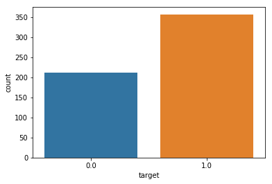

```python
# Definir quem são as variáveis 0 e 1
sns.countplot(df_cancer['target'])
```

## VISUALIZANDO DADOS

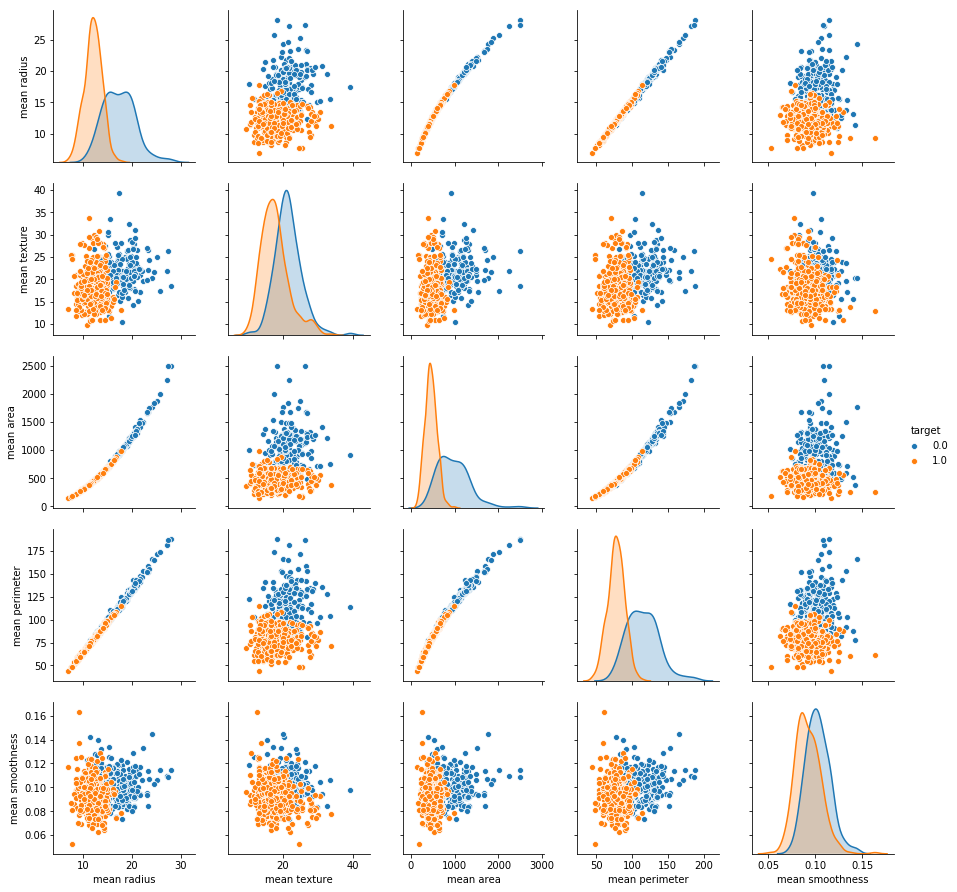

```python
sns.pairplot(df_cancer,  hue = 'target', vars = ['mean radius', 'mean texture', 'mean area', 'mean perimeter', 'mean smoothness'])
```

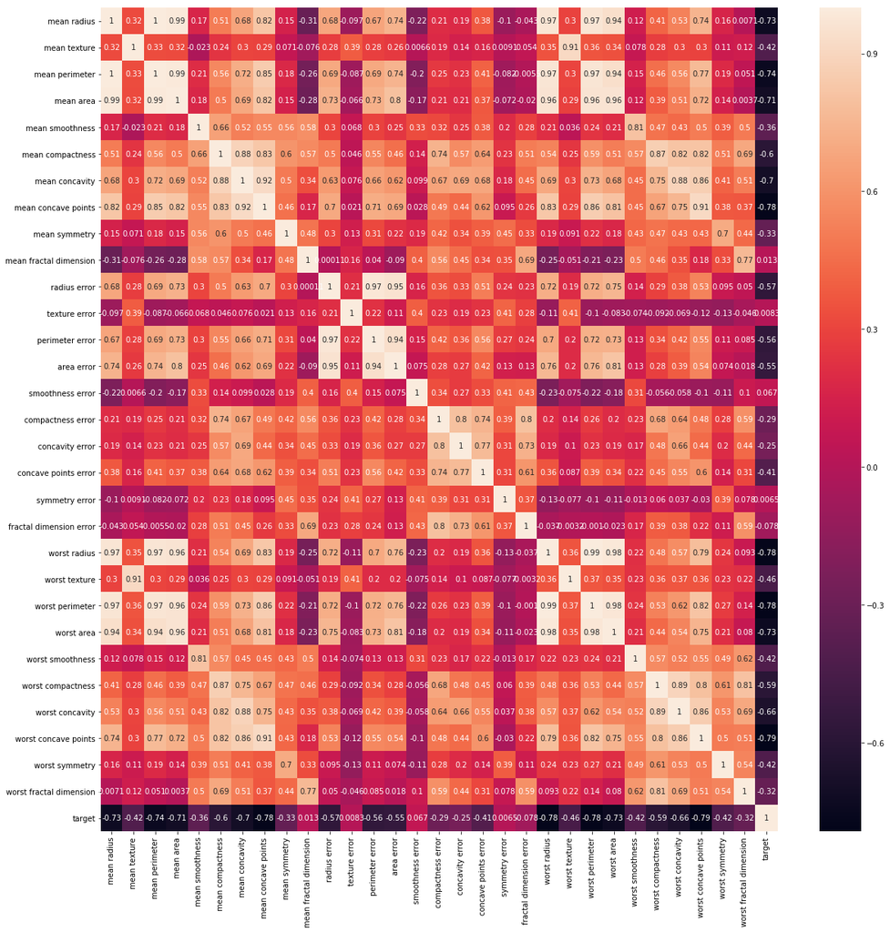

```python
# Correlação entre as variáveis
plt.figure(figsize=(20,20))
sns.heatmap(df_cancer.corr(), annot=True)
```

Através dos gráficos acima é possível ver que as variáveis independentes relacionadas com a geometria do tumor possuem uma elevada correlação umas com as outras, enquanto parâmetros como a textura e a suavidade apresentam correlações menores.